# Tools and Methods of Data Analysis

## Session 2

Niels Hoppe <niels.hoppe.extern@srh.de>

### Agenda 01/06

- Empirical Distributions
- Statistical Parameters
  - Measures of Central Tendency
  - Measures of Dispersion

### Empirical Distributions

- Qualitative variables
- Discrete quantitative variables
- Continuous quantitative variables

#### Distributions of Qualitative Variables

Variables on nominal or ordinal scale.

How often does a specific value / category occur?

```python
import pandas as pd
import seaborn as sns

labels = ['A', 'B', 'C', 'D', 'F']
df = pd.DataFrame(labels).sample(30, replace=True)

print(df[0].to_numpy())
```

```
['A' 'B' 'A' 'B' 'A' 'F' 'D' 'F' 'F' 'C' 'A' 'A' 'A' 'F' 'D' 'B' 'C' 'B'
 'C' 'F' 'B' 'A' 'D' 'A' 'D' 'A' 'D' 'F' 'B' 'D']
```

```python
df.describe()
```

|  | 0 |
| --- | --- |
| count | 30 |
| unique | 5 |
| top | A |
| freq | 9 |

Absolute frequency

```python
abs = df.value_counts()
abs
```

```
A    9
B    6
D    6
F    6
C    3
dtype: int64
```

Absolute frequency

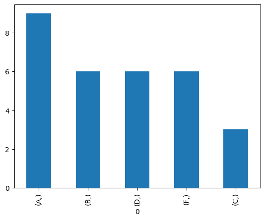

```python
abs.plot.bar()
```

Relative frequency

```python
rel = df.value_counts(normalize=True)
rel
```

```
A    0.3
B    0.2
D    0.2
F    0.2
C    0.1
dtype: float64
```

Relative frequency

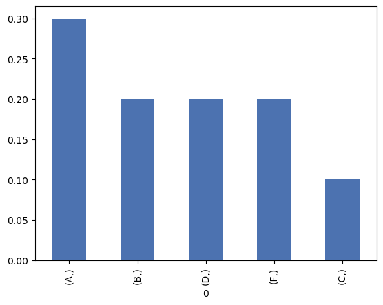

```python
rel.plot.bar(color=sns.color_palette('deep')[0])
```

Relative frequency

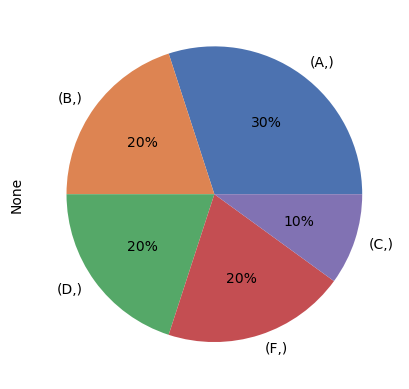

```python
rel = df.value_counts(normalize=True)
rel.plot.pie(colors=sns.color_palette('deep')[0:5], autopct='%.0f%%')
```

#### Distributions of Discrete Variables

```python
import pandas as pd
import seaborn as sns

df = pd.DataFrame([1, 2, 3, 4, 5, 6, 7, 8, 9]).sample(30, replace=True)

print(df[0].to_numpy())
```

```
[7 3 4 4 2 2 9 2 8 5 7 3 7 2 6 3 5 7 3 4 2 7 9 5 8 2 4 1 5 8]
```

#### Distributions of Discrete Variables

```
array([[<matplotlib.axes._subplots.AxesSubplot object at 0x7f851d83af10>]],
      dtype=object)
```

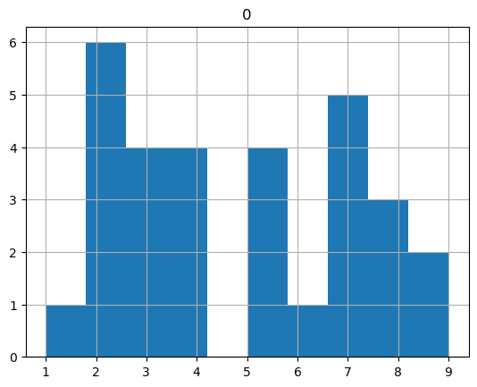

```python
df.hist()
```

#### Distributions of Discrete Variables

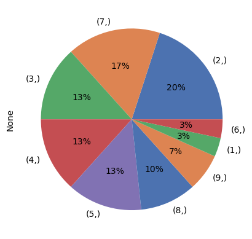

```python
df.value_counts().plot.pie(colors=sns.color_palette('deep')[0:5], autopct='%.0f%%')
```

#### Distributions of Discrete Variables

```python
cumsum = df.value_counts().sort_index().cumsum()
cumsum
```

```
1     1
2     7
3    11
4    15
5    19
6    20
7    25
8    28
9    30
dtype: int64
```

#### Distributions of Discrete Variables

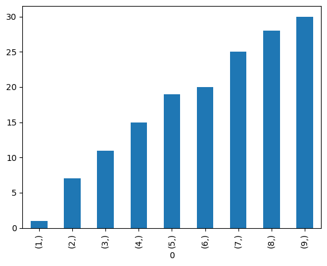

```python
cumsum.plot.bar()
```

#### Distributions of Discrete Variables

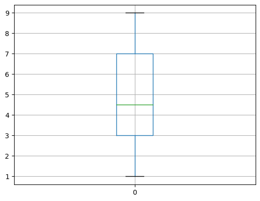

```python
df.boxplot()
```

#### Distributions of Continuous Variables

```python
import pyreadr

data = pyreadr.read_r('../data/devore7/ex01.36.rda')
df = data['ex01.36']
df
```

| rownames | C1 |
| --- | --- |
| 1 | 389 |
| 2 | 356 |
| 3 | 359 |
| 4 | 363 |
| 5 | 375 |
| 6 | 424 |
| 7 | 325 |
| 8 | 394 |
| 9 | 402 |
| 10 | 373 |
| 11 | 373 |
| 12 | 370 |
| 13 | 364 |
| 14 | 366 |
| 15 | 364 |
| 16 | 325 |
| 17 | 339 |
| 18 | 393 |
| 19 | 392 |
| 20 | 369 |
| 21 | 374 |
| 22 | 359 |
| 23 | 356 |
| 24 | 403 |
| 25 | 334 |
| 26 | 397 |

#### Distributions of Continuous Variables

```
array([[<matplotlib.axes._subplots.AxesSubplot object at 0x7f851d6b4a60>]],
      dtype=object)
```

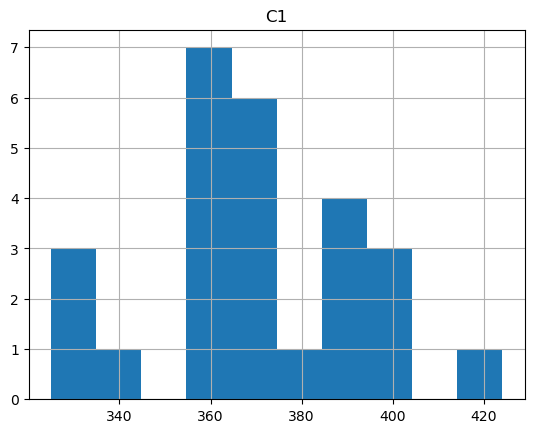

```python
df.hist(bins=10)
```

#### Distributions of Continuous Variables

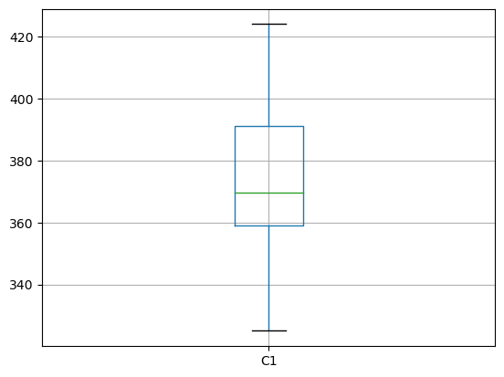

```python
df.boxplot()
```

### Caveats for the Presentation of Data

Presentation of data should be

- effective
- unambiguous and precise
- accessible

For ethical reasons, make sure to

- show relevant facts
- not conceal unfavorable findings

### Caveats for the Presentation of Data (cont.)

Example: Misleading presentation of relative and absolute frequencies.

```python
df = pd.DataFrame([(30, 300), (10, 100), (5, 50), (20, 200)],
        columns=['infections', 'patients'],
        index=['A', 'B', 'C', 'D'])
df['relative'] = df['infections'] / df['patients']

df
```

|  | infections | patients | relative |
| --- | --- | --- | --- |
| A | 30 | 300 | 0.1 |
| B | 10 | 100 | 0.1 |
| C | 5 | 50 | 0.1 |
| D | 20 | 200 | 0.1 |

### Caveats for the Presentation of Data (cont.)

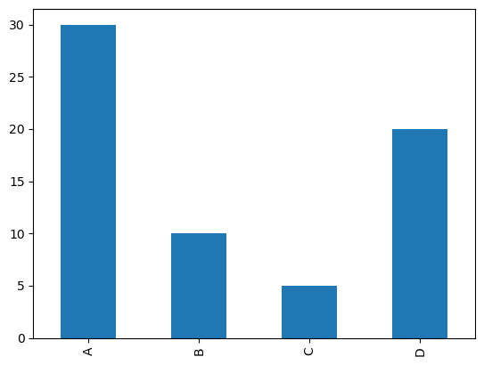

```python
df['infections'].plot.bar()
```

### Caveats for the Presentation of Data (cont.)

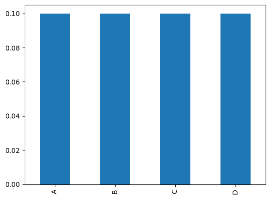

```python
df['relative'].plot.bar()
```

### Caveats for the Presentation of Data (cont.)

The point of origin must be recognizable!

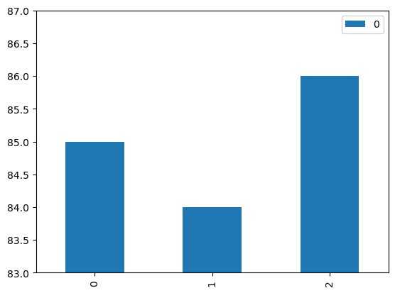

```python
df = pd.DataFrame([85, 84, 86])
df.plot.bar(ylim=(83,87))
```

### Caveats for the Presentation of Data (cont.)

The point of origin must be recognizable!

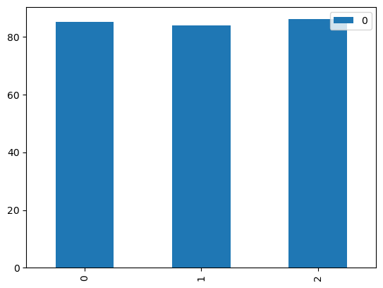

```python
df.plot.bar()
```

### Statistical Parameters

- Measures of Central Tendency
- Measures of Dispersion

### Measures of Central Tendency

- (Arithmetic) Mean
- Geometric mean
- Harmonic mean
- Median
- Mode

#### (Arithmetic) Mean

- https://pandas.pydata.org/pandas-docs/stable/reference/api/pandas.DataFrame.mean.html

```python
df = pd.DataFrame([(1,   0.5),
                   (0.5, 1),
                   (2,   1)], columns=('value', 'weight'))

mean = df.loc[:, 'value'].mean()
mean
```

```
1.1666666666666667
```

```python
wmean = np.average(a=df.loc[:, 'value'], weights=df.loc[:, 'weight'])
wmean
```

```
1.2
```

#### Geometric Mean

- https://docs.scipy.org/doc/scipy/reference/generated/scipy.stats.gmean.html

Example from https://en.wikipedia.org/wiki/Geometric_mean#Proportional_growth

```python
df = pd.DataFrame([(100, np.NaN),
                   (180, 180 / 100),
                   (210, 210 / 180),
                   (300, 300 / 210)], columns=['yield', 'growth'])

df
```

|  | yield | growth |
| --- | --- | --- |
| 0 | 100 | NaN |
| 1 | 180 | 1.800000 |
| 2 | 210 | 1.166667 |
| 3 | 300 | 1.428571 |

#### Geometric Mean (cont.)

```python
mean = df.loc[:, 'growth'].mean()
mean
```

```
1.4650793650793652
```

```python
from scipy import stats

gmean = stats.gmean(df.loc[:, 'growth'].dropna(), axis=0)
gmean
```

```
1.4422495703074085
```

```python
print('Actual yield:   ', 300)
print('Arithmetic mean:', 100 * mean ** 3)
print('Geometric mean: ', 100 * gmean ** 3)
```

```
Actual yield:    300
Arithmetic mean: 314.4730658636177
Geometric mean:  300.0000000000001
```

#### Harmonic Mean

Example from https://en.wikipedia.org/wiki/Harmonic_mean#Average_speed

- https://docs.scipy.org/doc/scipy/reference/generated/scipy.stats.hmean.html

```python
df = pd.DataFrame([60, 20], columns=['speed'])

mean = df.loc[:, 'speed'].mean()
mean
```

```
40.0
```

```python
hmean = stats.hmean(df.loc[:, 'speed'])
hmean
```

```
30.0
```

```python
print('Actual time:    ', 100 / 60 + 100 / 20)
print('Arithmetic mean:', 200 / mean)
print('Harmonic mean:  ', 200 / hmean)
```

```
Actual time:     6.666666666666667
Arithmetic mean: 5.0
Harmonic mean:   6.666666666666667
```

#### Harmonic Mean (cont.)

```python
df = pd.DataFrame([(200, 100),
                   (300, 50)], columns=['distance', 'speed'])

mean = df.loc[:, 'speed'].mean()
mean
```

```
75.0
```

```python
#hmean = stats.hmean(df.loc[:, 'speed'], weights=df.loc[:, 'distance'])
```

#### Median

The **median** of a set of values is the **value separating the lower half from the higher half** of all values.

- https://en.wikipedia.org/wiki/Median
- https://pandas.pydata.org/pandas-docs/stable/reference/api/pandas.DataFrame.median.html

Median (cont.)

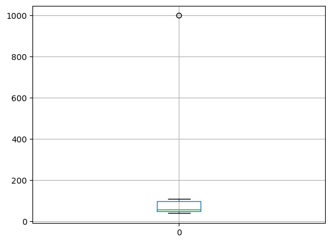

```python
df = pd.DataFrame([40, 50, 60, 45, 55, 50, 90, 100, 110, 1000])

df.boxplot()
```

#### Median (cont.)

```python
df.mean()
```

```
0    160.0
dtype: float64
```

```python
df.median()
```

```
0    57.5
dtype: float64
```

#### Mode

The **mode** of a set of values is the **value that appears most often**. It can be multiple values.

- https://en.wikipedia.org/wiki/Mode_(statistics)
- https://pandas.pydata.org/pandas-docs/stable/reference/api/pandas.DataFrame.mode.html

```python
df.mode()
```

|  | 0 |
| --- | --- |
| 0 | 50 |

### Measures of Dispersion

- Range
- Quantiles, Quartiles, Interquartile Range
- Variance
- Standard Deviation
- Coefficient of Variation

#### Range

The **range** is of a set of data is the difference between the smallest and largest value.

```python
range = df.max() - df.min()
range
```

```
0    960
dtype: int64
```

#### Quantiles, Quartiles, Interquartile Range

Quantile:

- Value greater than or equal to a specified percentage of all values. (inclusive definition)
- Value greater than a specified percentage of all values. (exclusive definition)

Quartiles and deciles and percentiles are special quantiles:

- Quartile: Any of three values dividing the data into four equal parts.
- Decile: Any of nine values dividing the data into ten equal parts.
- Percentile: Any of 99 values dividing the data into 100 equal parts.

The following equalities hold:

- 25th percentile = 1st quartile (Q1)
- 50th percentile = 2nd quartile (Q2) = 5th decile (D5) = median
- 75th percentile = 3rd quartile (Q3)

#### Quantiles, Quartiles, Interquartile Range (cont.)

- https://pandas.pydata.org/pandas-docs/stable/reference/api/pandas.DataFrame.quantile.html

```python
p25, p75 = np.percentile(df[0], [25, 75])

quartiles = df[0].quantile([0.25, 0.5, 0.75])

quartiles
```

```
0.25    50.0
0.50    57.5
0.75    97.5
Name: 0, dtype: float64
```

#### Quantiles, Quartiles, Interquartile Range (cont.)

```python
q1, q3 = df[0].quantile([0.25, 0.75])

iqr = q3 - q1

iqr
```

```
47.5
```

#### Trimmed Mean

```python
stats.trim_mean(df[0], 0.1)
```

```
70.0
```

#### Variance

- https://en.wikipedia.org/wiki/Variance
- https://pandas.pydata.org/pandas-docs/stable/reference/api/pandas.DataFrame.var.html

```python
df[0].var()
```

```
87716.66666666667
```

```python
df[0].var(ddof=0)
```

```
78945.0
```

#### Standard Deviation

- https://en.wikipedia.org/wiki/Standard_deviation
- https://pandas.pydata.org/pandas-docs/stable/reference/api/pandas.DataFrame.std.html

```python
df[0].std()
```

```
296.1699962296429
```

```python
df[0].std(ddof=0)
```

```
280.9715288067458
```

#### Coefficient of Variation

- https://en.wikipedia.org/wiki/Coefficient_of_variation

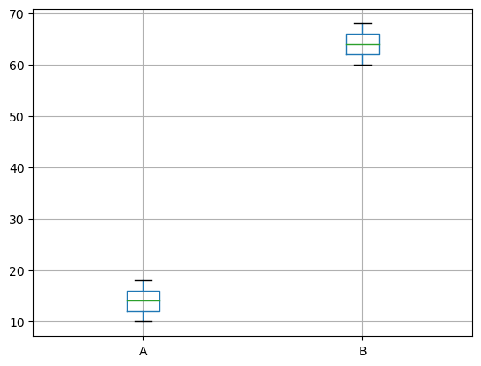

```python
df = pd.DataFrame([(10, 60), (12, 62), (14, 64),
                   (16, 66), (18, 68)], columns=['A', 'B'])

df.boxplot()
```

#### Coefficient of Variation (cont.)

```python
df.std()
```

```
A    3.162278
B    3.162278
dtype: float64
```

```python
cov = df.std() / df.mean()
cov
```

```
A    0.225877
B    0.049411
dtype: float64
```